# Microdata (IPUMS)

Ryan Brenner

Updated: Tue, Nov 25, 2025 at 04:12 PM

```r
library(tidyverse)
library(tidycensus)
library(srvyr)
```

# Background

IPUMS, originally the Integrated Public Use Microdata Series, is a database of Census microdata housed at the Institute for Social Research and Data Innovation (ISRDI) at the University of Minnesota. Whereas the published tables of the American Community Survey provide pre-calculated indicators and aggregated statistics for predefined geographies, IPUMS offers anonymized versions of the underlying person- and household-level records. Access to these raw microdata enables finer-grained analysis and the ability to create cross-tabulations of variables that are not combined in standard ACS products.

**Example**

The ACS surveys renter-occupied households about their rent. Whereas Table B25064 provides the median rent for a given geography, Table B25063 provides a distribution of rent amountrs. However, the bins are pre-set with bin widths of $50 for rents under $800, $100 for rents under $1,000, $250 for rents under $1,500, $500 for rents under $3,500, and then a ceiling of $3,500. With a citywide median of around $1,700, these bin widths are not ideal for analyzing NYC rents.

```r
acs_rent <-
  tidycensus::get_acs(
    geography = "county",
    state = "36",
    county = c("005", "047", "061", "081", "085"),
    table = "B25063",
    year = 2023,
    survey = "acs1"
  ) %>%
  dplyr::transmute(
    borough = dplyr::case_when(
      NAME == "Bronx County, New York"    ~ "Bronx",
      NAME == "Kings County, New York"    ~ "Brooklyn",
      NAME == "New York County, New York" ~ "Manhattan",
      NAME == "Queens County, New York"   ~ "Queens",
      NAME == "Richmond County, New York" ~ "Staten_Island"
    ),
    rent = dplyr::case_when(
      variable == "B25063_001" ~ "DROP", #Total
      variable == "B25063_002" ~ "DROP", #With cash rent
      variable == "B25063_003" ~ "0-99",
      variable == "B25063_004" ~ "100-149",
      variable == "B25063_005" ~ "150-199",
      variable == "B25063_006" ~ "200-249",
      variable == "B25063_007" ~ "250-299",
      variable == "B25063_008" ~ "300-349",
      variable == "B25063_009" ~ "350-399",
      variable == "B25063_010" ~ "400-449",
      variable == "B25063_011" ~ "450-499",
      variable == "B25063_012" ~ "500-549",
      variable == "B25063_013" ~ "550-599",
      variable == "B25063_014" ~ "600-649",
      variable == "B25063_015" ~ "650-699",
      variable == "B25063_016" ~ "700-749",
      variable == "B25063_017" ~ "750-799",
      variable == "B25063_018" ~ "800-899",
      variable == "B25063_019" ~ "900-999",
      variable == "B25063_020" ~ "1000-1249",
      variable == "B25063_021" ~ "1250-1499",
      variable == "B25063_022" ~ "1500-1999",
      variable == "B25063_023" ~ "2000-2499",
      variable == "B25063_024" ~ "2500-2999",
      variable == "B25063_025" ~ "3000-3499",
      variable == "B25063_026" ~ "3500-Inf",
      variable == "B25063_027" ~ "DROP" #No cash rent
    ),
    count = estimate
  ) %>%
  dplyr::filter(rent != "DROP") %>%
  tidyr::pivot_wider(names_from = borough, values_from = count) %>%
  tidyr::separate(
    rent,
    into = c("Bin_Min", "Bin_Max"),
    sep = "-"
  )

acs_rent %>%
  DT::datatable() %>%
  DT::formatCurrency(c("Bin_Min", "Bin_Max"), currency = "$", digits = 0) %>%
  DT::formatRound(c("Bronx", "Brooklyn", "Manhattan", "Queens", "Staten_Island"), digits = 0)
```

|  | Bin_Min | Bin_Max | Bronx | Brooklyn | Manhattan | Queens | Staten_Island |
| --- | --- | --- | --- | --- | --- | --- | --- |
| 1 | 0 | 99 | 573 | 1357 | 1361 | 678 | 0 |
| 2 | 100 | 149 | 1953 | 1858 | 1499 | 309 | 528 |
| 3 | 150 | 199 | 2371 | 2515 | 2260 | 256 | 325 |
| 4 | 200 | 249 | 7743 | 9508 | 7306 | 3732 | 1521 |
| 5 | 250 | 299 | 13790 | 17190 | 12020 | 4739 | 699 |
| 6 | 300 | 349 | 10176 | 10405 | 9294 | 4058 | 1266 |
| 7 | 350 | 399 | 8034 | 5696 | 6476 | 2886 | 135 |
| 8 | 400 | 449 | 5215 | 7795 | 5943 | 1564 | 152 |
| 9 | 450 | 499 | 3626 | 5327 | 5124 | 1465 | 141 |
| 10 | 500 | 549 | 5082 | 8139 | 5529 | 2822 | 833 |

[output cut: 14 more lines]

IPUMS provides the underlying microdata, allowing this table to be re-binned.

```r
ipums_rent <-
  readr::read_csv("C:/Users/brenner/Documents/GitHub/R_Census/Data/nyc_micro_rent.csv") %>%
  dplyr::transmute(
    household = SERIAL,
    HHWT,
    borough = dplyr::case_when(
      COUNTYFIP == 5  ~ "Bronx",
      COUNTYFIP == 47 ~ "Brooklyn",
      COUNTYFIP == 61 ~ "Manhattan",
      COUNTYFIP == 81 ~ "Queens",
      COUNTYFIP == 85 ~ "Staten_Island"
    ),
    rent = dplyr::case_when(
      RENTGRS <   500 ~ "0-499",
      RENTGRS <  1000 ~ "500-999",
      RENTGRS <  1500 ~ "1000-1499",
      RENTGRS <  2000 ~ "1500-1999",
      RENTGRS <  2500 ~ "2000-2499",
      RENTGRS <  3000 ~ "2500-2999",
      RENTGRS <  3500 ~ "3000-3499",
      RENTGRS <  4000 ~ "3500-3999",
      RENTGRS <  4500 ~ "4000-4499",
      RENTGRS <  5000 ~ "4500-4999",
      RENTGRS >= 5000 ~ "5000-Inf"
    )
  ) %>%
  dplyr::transmute(
    household,
    HHWT,
    group = stringr::str_c(borough, rent, sep = "-")
  ) %>%
  dplyr::distinct(household, .keep_all = TRUE) %>%
  srvyr::as_survey(weights = HHWT) %>%
  dplyr::summarize(
    .by = group,
    count = srvyr::survey_total()
  ) %>%
  tidyr::separate(
    group,
    into = c("borough", "Bin_Min", "Bin_Max"),
    sep = "-"
  ) %>%
  dplyr::select(-count_se) %>%
  tidyr::pivot_wider(names_from = borough, values_from = count)

ipums_rent %>%
  dplyr::arrange(as.double(Bin_Min)) %>%
  DT::datatable() %>%
  DT::formatCurrency(c("Bin_Min", "Bin_Max"), currency = "$", digits = 0) %>%
  DT::formatRound(c("Bronx", "Brooklyn", "Manhattan", "Queens", "Staten_Island"), digits = 0)
```

|  | Bin_Min | Bin_Max | Bronx | Brooklyn | Manhattan | Queens | Staten_Island |
| --- | --- | --- | --- | --- | --- | --- | --- |
| 1 | 0 | 499 | 52211 | 62168 | 52022 | 20223 | 4620 |
| 2 | 500 | 999 | 61139 | 68323 | 66144 | 36663 | 6565 |
| 3 | 1000 | 1499 | 133595 | 141061 | 77721 | 81151 | 10073 |
| 4 | 1500 | 1999 | 102553 | 163375 | 70516 | 125898 | 13768 |
| 5 | 2000 | 2499 | 43841 | 112762 | 62375 | 105373 | 8452 |
| 6 | 2500 | 2999 | 15881 | 62112 | 47274 | 49019 | 5868 |
| 7 | 3000 | 3499 | 3868 | 38015 | 44445 | 18536 | 1976 |
| 8 | 3500 | 3999 | 2527 | 22753 | 36744 | 10580 | 1055 |
| 9 | 4000 | 4499 | 1353 | 17982 | 31080 | 6482 | 715 |
| 10 | 4500 | 4999 | 1364 | 7969 | 20448 | 2842 | 86 |

[output cut: 1 more lines]

# Extracting Data

IPUMS data is available online at https://usa.ipums.org/usa/. Register for an account and click “Get Data” to start.

### Select Samples

These are the datasets to pull from.

[figure not shown]

### Select Geography

Microdata available through IPUMS is only labeled at the PUMA-level and higher (roughly equivalent to Community Districts in NYC). Selecting geographic data does not impact which records are sampled (a filter is required for that), it just provides a code to group on.

[figure not shown]

### Select Variables

IPUMS tries to harmonize variables across datasets, but make sure the variable(s) selected match the use-case and are available for all years. The metadata also provides info on top coding and other categorizations.

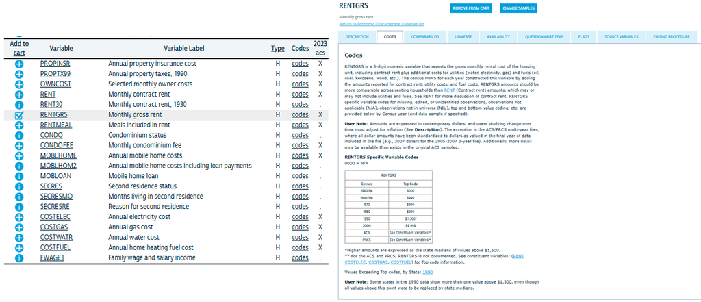

### View Data Cart

Ensure everything is correct, and then click “Create Data Extract”.

[figure not shown]

### Modify Extract

From this page you can:

- Change the file output to CSV
- Select cases (i.e. filter the sample) by state
- Adjust monetary values to 2010

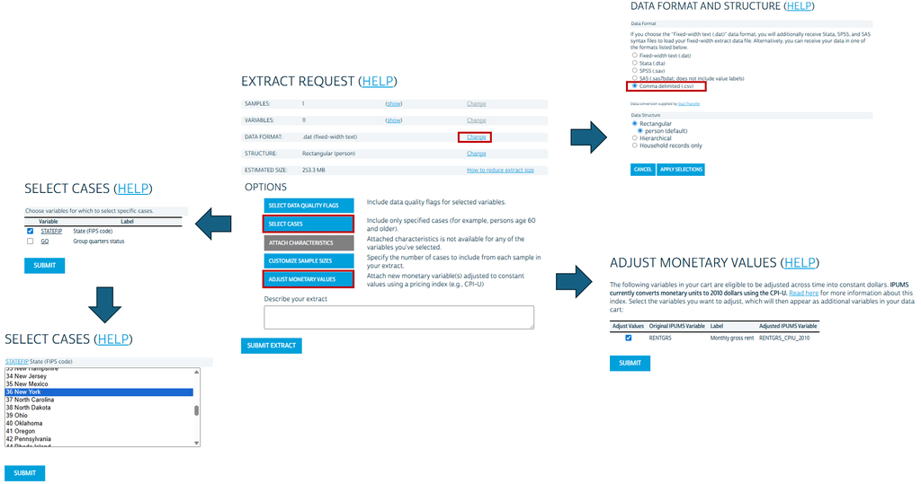

### Download

Once the extract is completed, download the CSV. The download will likely show up as a .csv.gz file, so use 7-Zip to extract the zipped file instead of the default Windows option (Windows Explorer sometimes misinterprets .gz files and produces thousands of fragments).

[figure not shown]

The data is now ready to use!

```r
readr::read_csv("C:/Users/brenner/Documents/GitHub/R_Census/Data/nyc_micro_rent.csv") %>% head()
```

```
## # A tibble: 6 × 12
##    YEAR SAMPLE SERIAL     CBSERIAL  HHWT CLUSTER STATEFIP COUNTYFIP STRATA    GQ
##   <dbl>  <dbl>  <dbl>        <dbl> <dbl>   <dbl>    <dbl>     <dbl>  <dbl> <dbl>
## 1  2023 202301 897328      2.02e12    85 2.02e12       36        47 430536     1
## 2  2023 202301 897332      2.02e12    95 2.02e12       36        81 441336     1
## 3  2023 202301 897332      2.02e12    95 2.02e12       36        81 441336     1
## 4  2023 202301 897332      2.02e12    95 2.02e12       36        81 441336     1
## 5  2023 202301 897332      2.02e12    95 2.02e12       36        81 441336     1
## 6  2023 202301 897335      2.02e12   365 2.02e12       36        61 410336     1
## # ℹ 2 more variables: RENTGRS <dbl>, RENTGRS_CPIU_2010 <dbl>
```

# Analyzing a Survey

Unlike the ACS, which provides cleaned estimates with margins of error, IPUMS is messy survey data that must be processed before producing estimates. However, unlike the NYC Housing and Vacancy Survey which has dozens of replicate weights to account for, IPUMS is much easier to work with. All that is needed is to create a survey object with the weight specified as either the household or person weight. (Note: IPUMS data is always provided at the person-level where each row represents a person. This is true even if all of the variables selected are household-level variables - in which case the household-level variables are repeated across all individuals in the household. When using person-level variables, use all records and the `PERWT` weight; when using household-level variables, first select only one row per household/`SERIAL` and then use the `HHWT` weight.)

```r
#Household-level data
ipums_hh_data %>%
  #Select one row per household
  dplyr::distinct(SERIAL, .keep_all = TRUE) %>%
  srvyr::as_survey(weights = HHWT)
```

```r
#Person-level data
ipums_ind_data %>%
  srvyr::as_survey(weights = PERWT)
```

```r
#Mixed data
ipums_mix_data %>%
  #Select specific row per household, in this case Head of Household
  dplyr::filter(RELATE == 1) %>%
  srvyr::as_survey(weights = HHWT)
```

Once the survey object is created, `srvyr` has a series of functions that calculate estimates with margins of error.

- `survey_total()` for counts
- `survey_total(col)` for sums
- `survey_mean(col)` for means
- `survey_median(col)` for medians
- `survey_quantile(col, quantiles = x)` for other quantiles
- Etc.

```r
readr::read_csv("C:/Users/brenner/Documents/GitHub/R_Census/Data/nyc_micro_rent.csv") %>%
  dplyr::distinct(SERIAL, .keep_all = TRUE) %>%
  srvyr::as_survey(weights = HHWT) %>%
  dplyr::summarize(
    median_rent = srvyr::survey_median(RENTGRS, na.rm = TRUE),
    mean_rent = srvyr::survey_mean(RENTGRS, na.rm = TRUE)
  )
```

```
## # A tibble: 1 × 4
##   median_rent median_rent_se mean_rent mean_rent_se
##         <dbl>          <dbl>     <dbl>        <dbl>
## 1        1730           15.8     2015.         15.1
```

When grouping, `summarize()` fails with multiple `.by` arguments, so multiple grouping variables should be concatenated before summarizing.

```r
readr::read_csv("C:/Users/brenner/Documents/GitHub/R_Census/Data/nyc_micro_rent.csv") %>%
  #Create new variables
  dplyr::transmute(
    household = SERIAL,
    HHWT,
    borough = dplyr::case_when(
      COUNTYFIP == 5  ~ "Bronx",
      COUNTYFIP == 47 ~ "Brooklyn",
      COUNTYFIP == 61 ~ "Manhattan",
      COUNTYFIP == 81 ~ "Queens",
      COUNTYFIP == 85 ~ "Staten_Island"
    ),
    rent = dplyr::case_when(
      RENTGRS <  1000 ~ "Super Low",
      RENTGRS <  1700 ~ "Below Median",
      RENTGRS <  5000 ~ "Above Median",
      RENTGRS >= 5000 ~ "Super High"
    ),
    RENTGRS
  ) %>%
  #Concatenate variables into one column
  dplyr::transmute(
    household,
    HHWT,
    group = stringr::str_c(borough, rent, sep = "-"),
    RENTGRS
  ) %>%
  dplyr::distinct(household, .keep_all = TRUE) %>%
  srvyr::as_survey(weights = HHWT) %>%
  #Group and analyze by the concatenated variable
  dplyr::summarize(
    .by = group,
    rent = srvyr::survey_median(RENTGRS, na.rm = TRUE)
  ) %>%
  #Split the concatenated variable back into multiple variables
  tidyr::separate(
    group,
    into = c("borough", "rent_level"),
    sep = "-"
  ) %>%
  dplyr::select(-rent_se) %>%
  tidyr::pivot_wider(names_from = borough, values_from = rent) %>%
  DT::datatable() %>%
  DT::formatCurrency(c("Bronx", "Brooklyn", "Manhattan", "Queens", "Staten_Island"), digits = 0)
```

|  | rent_level | Bronx | Brooklyn | Manhattan | Queens | Staten_Island |
| --- | --- | --- | --- | --- | --- | --- |
| 1 | Above Median | 2050 | 2330 | 2880 | 2200 | 2260 |
| 2 | Below Median | 1340 | 1380 | 1300 | 1390 | 1440 |
| 3 | Super High | 5100 | 6370 | 6105 | 5800 | 7700 |
| 4 | Super Low | 530 | 510 | 560 | 660 | 550 |